# Sixth Week: Linear Models

House price prediction

benyamin jami al ahmadi 94105282

2018-04-14 02:11:21

> با توجه به داده های قیمت منازل لطفا با سوالات زیر پاسخ دهید.

۱. ماتریس همبستگی متغیرهای مختلف را به دست آورده و سپس رسم نمایید. اعداد به دست آمده را با آزمون فرض معناداری همبستگی بسنجید و سپس ده متغیری که همبستگی بالاتری با قیمت دارند را مشخص نمایید.

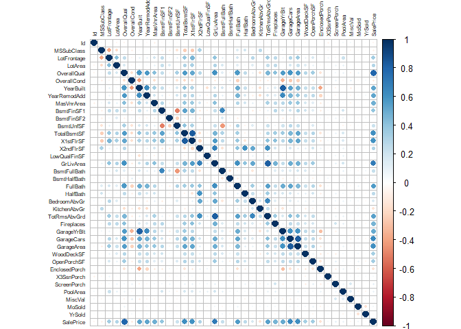

```r
house_num = house %>% select_if(is.numeric)
house_cor = cor(house_num, method = "pearson" , use = "complete.obs")
corrplot(house_cor,tl.cex = 0.5,tl.col = "black")
```

```r
ans1 = c()
for(i in 1:38)
{
  ans1 = c(ans1, cor.test(house_num$SalePrice, house_num[, i])$estimate)
}
corr_value = data.frame(parameter = colnames(house_num), correlation = ans1)
corr_value %>% arrange(desc(correlation)) %>% slice(2:11) %>%
  select(parameter) -> ans1
ans1
```

```
## # A tibble: 10 x 1
##       parameter
##          <fctr>
##  1  OverallQual
##  2    GrLivArea
##  3   GarageCars
##  4   GarageArea
##  5  TotalBsmtSF
##  6    X1stFlrSF
##  7     FullBath
##  8 TotRmsAbvGrd
##  9    YearBuilt
## 10 YearRemodAdd
```

۲. در یک تصویر نمودار پراکنش دو به دو ده متغیر بدست آمده به همراه قیمت را رسم نمایید و هم خطی بودن متغیرها را بررسی کنید

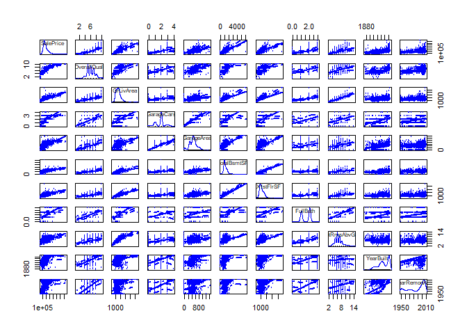

```r
par = (mfrow=c(11,11))
house_num %>% select(SalePrice, as.character(ans1$parameter)) -> data2
data2 %>% scatterplotMatrix(cex = 0.05)
```

۳. یک مدل خطی بر اساس ده متغیر برای پیش بینی قیمت برازش دهید. و سپس خلاصه نتایج مدل را به دست آورید.

```r
fit = lm(data = data2 , formula = SalePrice ~ .)
summary(fit)
```

```
##
## Call:
## lm(formula = SalePrice ~ ., data = data2)
##
## Residuals:
##     Min      1Q  Median      3Q     Max
## -489958  -19316   -1948   16020  290558
##
## Coefficients:
##                Estimate Std. Error t value Pr(>|t|)
## (Intercept)  -1.186e+06  1.291e+05  -9.187  < 2e-16 ***
## OverallQual   1.960e+04  1.190e+03  16.472  < 2e-16 ***
## GrLivArea     5.130e+01  4.233e+00  12.119  < 2e-16 ***
## GarageCars    1.042e+04  3.044e+03   3.422 0.000639 ***
## GarageArea    1.495e+01  1.031e+01   1.450 0.147384
## TotalBsmtSF   1.986e+01  4.295e+00   4.625 4.09e-06 ***
## X1stFlrSF     1.417e+01  4.930e+00   2.875 0.004097 **
## FullBath     -6.791e+03  2.682e+03  -2.532 0.011457 *
## TotRmsAbvGrd  3.310e+01  1.119e+03   0.030 0.976404
## YearBuilt     2.682e+02  5.035e+01   5.328 1.15e-07 ***
## YearRemodAdd  2.965e+02  6.363e+01   4.659 3.47e-06 ***
## ---
## Signif. codes:  0 '***' 0.001 '**' 0.01 '*' 0.05 '.' 0.1 ' ' 1
##
## Residual standard error: 37920 on 1449 degrees of freedom
## Multiple R-squared:  0.7737, Adjusted R-squared:  0.7721
## F-statistic: 495.4 on 10 and 1449 DF,  p-value: < 2.2e-16
```

۴. نمودار قیمت واقعی و قیمت پیش بینی را رسم نمایید و خوب بودن مدل را ارزیابی کنید.

```r
data.frame(SalePrice = data2$SalePrice , fitted = fit$fitted.values) -> data4
hchart(data4 , hcaes(x = SalePrice , y = fitted) , type = "scatter")
```

[interactive chart not shown]

```r
lm(data4$SalePrice~data4$fitted) %>% summary()
```

```
##
## Call:
## lm(formula = data4$SalePrice ~ data4$fitted)
##
## Residuals:
##     Min      1Q  Median      3Q     Max
## -489958  -19316   -1948   16020  290558
##
## Coefficients:
##               Estimate Std. Error t value Pr(>|t|)
## (Intercept)  2.437e-10  2.747e+03     0.0        1
## data4$fitted 1.000e+00  1.416e-02    70.6   <2e-16 ***
## ---
## Signif. codes:  0 '***' 0.001 '**' 0.01 '*' 0.05 '.' 0.1 ' ' 1
##
## Residual standard error: 37810 on 1458 degrees of freedom
## Multiple R-squared:  0.7737, Adjusted R-squared:  0.7735
## F-statistic:  4985 on 1 and 1458 DF,  p-value: < 2.2e-16
```

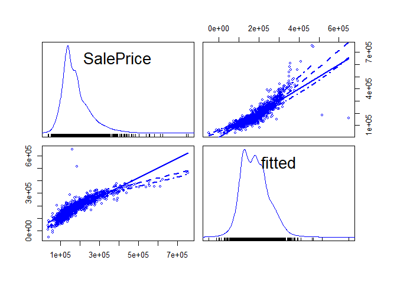

```r
scatterplotMatrix(data4,cex=0.7)
```

با توجه به مقادیر p-vlaue میتوان گفت مدل مناسبی است اما باید residuals نیز مورد بررسی قرار گیرند.

۵. مقدار R-squared مدل را به دست آورید. آیا بر اساس این کمیت مدل به خوبی به داده ها برازش داده شده است؟ کمیت F-statistic را در خلاصه مدل تفسیر نمایید.

```r
data5 = summary(fit)
data5$r.squared
```

```
## [1] 0.7736928
```

```r
data5$fstatistic
```

```
##     value     numdf     dendf
##  495.3802   10.0000 1449.0000
```

r-squared مقداری آماری جهت نشان دادن آن است که داده چقدر به خط رگرسیون نزدیک استو عددی بین 1 تا 0 است و هر چه بیشتر باشد بهتر است که مقدار بدست آمده مقدار مناسبی میباشد. و از طرفی مقدار fstatistic هر چه بالاتز باشد بهتر است که مقدار بدست آمده مقدار خوبی است.

۶. بر اساس p-value سطح معناداری ضرایب تصمیم بگیرید که چه متغیرهایی در مدل سازی استفاده شود. بر اساس متغیرهای جدید دوباره مدل سازی کنید و نتایج رو گزارش دهید.

```r
var6 = ans1[-c(4,6,7,8),]
house %>% select("SalePrice",as.character(var6$parameter)) -> data6
lm(SalePrice ~ .,data = data6) -> fit2
summary(fit2) -> fits2
fits2$r.squared
```

```
## [1] 0.7709311
```

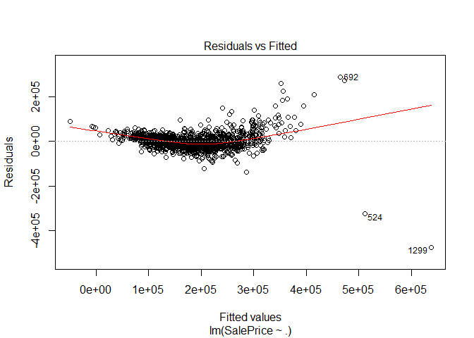

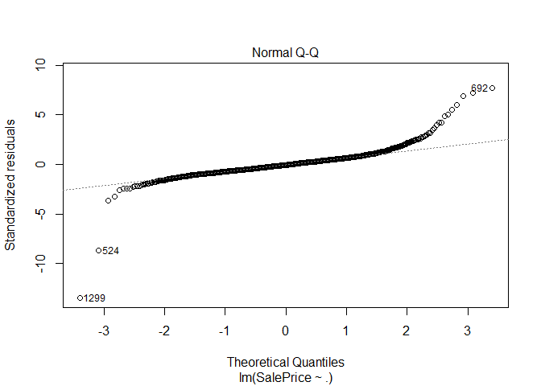

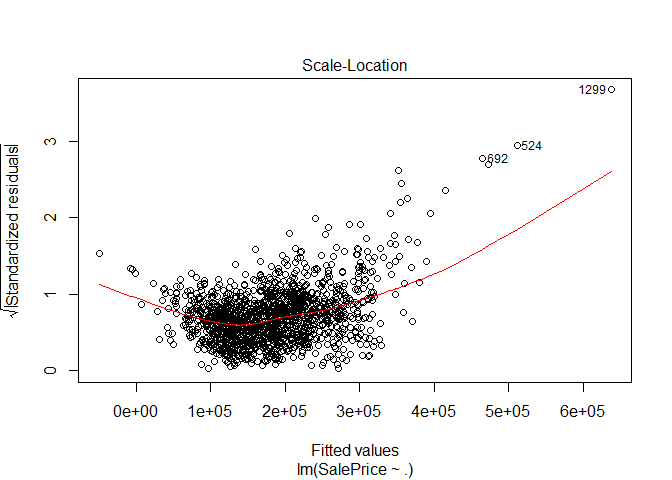

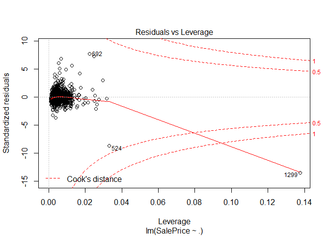

```r
plot(fit2)
```

متغیر ها با p-value بیشتر را حذف میکنیم.